# White Wine Quality Exploration by Dogan Askan

# Univariate Plots Section

This report explores a dataset containing quality and attributes for approximately 4,900 white wines.

```
## 'data.frame':    4898 obs. of  13 variables:
##  $ X                   : int  1 2 3 4 5 6 7 8 9 10 ...
##  $ fixed.acidity       : num  7 6.3 8.1 7.2 7.2 8.1 6.2 7 6.3 8.1 ...
##  $ volatile.acidity    : num  0.27 0.3 0.28 0.23 0.23 0.28 0.32 0.27 0.3 0.22 ...
##  $ citric.acid         : num  0.36 0.34 0.4 0.32 0.32 0.4 0.16 0.36 0.34 0.43 ...
##  $ residual.sugar      : num  20.7 1.6 6.9 8.5 8.5 6.9 7 20.7 1.6 1.5 ...
##  $ chlorides           : num  0.045 0.049 0.05 0.058 0.058 0.05 0.045 0.045 0.049 0.044 ...
##  $ free.sulfur.dioxide : num  45 14 30 47 47 30 30 45 14 28 ...
##  $ total.sulfur.dioxide: num  170 132 97 186 186 97 136 170 132 129 ...
##  $ density             : num  1.001 0.994 0.995 0.996 0.996 ...
##  $ pH                  : num  3 3.3 3.26 3.19 3.19 3.26 3.18 3 3.3 3.22 ...
##  $ sulphates           : num  0.45 0.49 0.44 0.4 0.4 0.44 0.47 0.45 0.49 0.45 ...
##  $ alcohol             : num  8.8 9.5 10.1 9.9 9.9 10.1 9.6 8.8 9.5 11 ...
##  $ quality             : int  6 6 6 6 6 6 6 6 6 6 ...
```

```
##        X        fixed.acidity    volatile.acidity  citric.acid
##  Min.   :   1   Min.   : 3.800   Min.   :0.0800   Min.   :0.0000
##  1st Qu.:1225   1st Qu.: 6.300   1st Qu.:0.2100   1st Qu.:0.2700
##  Median :2450   Median : 6.800   Median :0.2600   Median :0.3200
##  Mean   :2450   Mean   : 6.855   Mean   :0.2782   Mean   :0.3342
##  3rd Qu.:3674   3rd Qu.: 7.300   3rd Qu.:0.3200   3rd Qu.:0.3900
##  Max.   :4898   Max.   :14.200   Max.   :1.1000   Max.   :1.6600
##  residual.sugar     chlorides       free.sulfur.dioxide
##  Min.   : 0.600   Min.   :0.00900   Min.   :  2.00
##  1st Qu.: 1.700   1st Qu.:0.03600   1st Qu.: 23.00
##  Median : 5.200   Median :0.04300   Median : 34.00
##  Mean   : 6.391   Mean   :0.04577   Mean   : 35.31
##  3rd Qu.: 9.900   3rd Qu.:0.05000   3rd Qu.: 46.00
##  Max.   :65.800   Max.   :0.34600   Max.   :289.00
##  total.sulfur.dioxide    density             pH          sulphates
##  Min.   :  9.0        Min.   :0.9871   Min.   :2.720   Min.   :0.2200
##  1st Qu.:108.0        1st Qu.:0.9917   1st Qu.:3.090   1st Qu.:0.4100
##  Median :134.0        Median :0.9937   Median :3.180   Median :0.4700
##  Mean   :138.4        Mean   :0.9940   Mean   :3.188   Mean   :0.4898
##  3rd Qu.:167.0        3rd Qu.:0.9961   3rd Qu.:3.280   3rd Qu.:0.5500
##  Max.   :440.0        Max.   :1.0390   Max.   :3.820   Max.   :1.0800
##     alcohol         quality
##  Min.   : 8.00   Min.   :3.000
##  1st Qu.: 9.50   1st Qu.:5.000
##  Median :10.40   Median :6.000
##  Mean   :10.51   Mean   :5.878
##  3rd Qu.:11.40   3rd Qu.:6.000
##  Max.   :14.20   Max.   :9.000
```

It looks there are just 19 zeros in Citric Acid, and no NA values in the entire dataset.

```
## [1] "Non-Zero values in columns"
```

```
## [1] "4898 X"
## [1] "4898 fixed.acidity"
## [1] "4898 volatile.acidity"
## [1] "4879 citric.acid" "19 citric.acid"
## [1] "4898 residual.sugar"
## [1] "4898 chlorides"
## [1] "4898 free.sulfur.dioxide"
## [1] "4898 total.sulfur.dioxide"
## [1] "4898 density"
## [1] "4898 pH"
## [1] "4898 sulphates"
## [1] "4898 alcohol"
## [1] "4898 quality"
```

```
## [1] "Non-NA values in columns"
```

```
## [1] "4898 X"
## [1] "4898 fixed.acidity"
## [1] "4898 volatile.acidity"
## [1] "4898 citric.acid"
## [1] "4898 residual.sugar"
## [1] "4898 chlorides"
## [1] "4898 free.sulfur.dioxide"
## [1] "4898 total.sulfur.dioxide"
## [1] "4898 density"
## [1] "4898 pH"
## [1] "4898 sulphates"
## [1] "4898 alcohol"
## [1] "4898 quality"
```

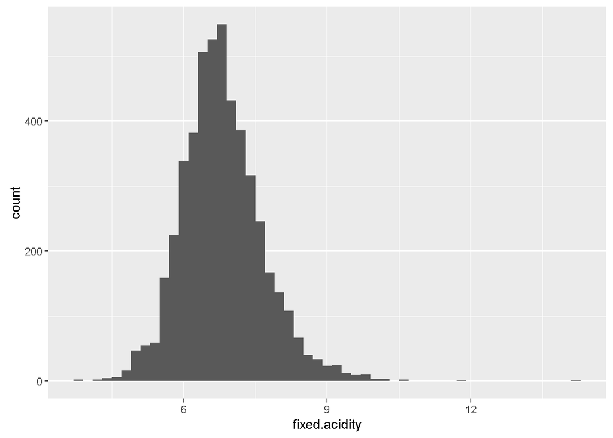

```
##    Min. 1st Qu.  Median    Mean 3rd Qu.    Max.
##   3.800   6.300   6.800   6.855   7.300  14.200
```

Fixed Acidity looks normally distributed. Skewness is very minor. There are just a few outliers. Fixed Acidity may be helpful in further analysis due to its relation with pH and Volatile Acidity.

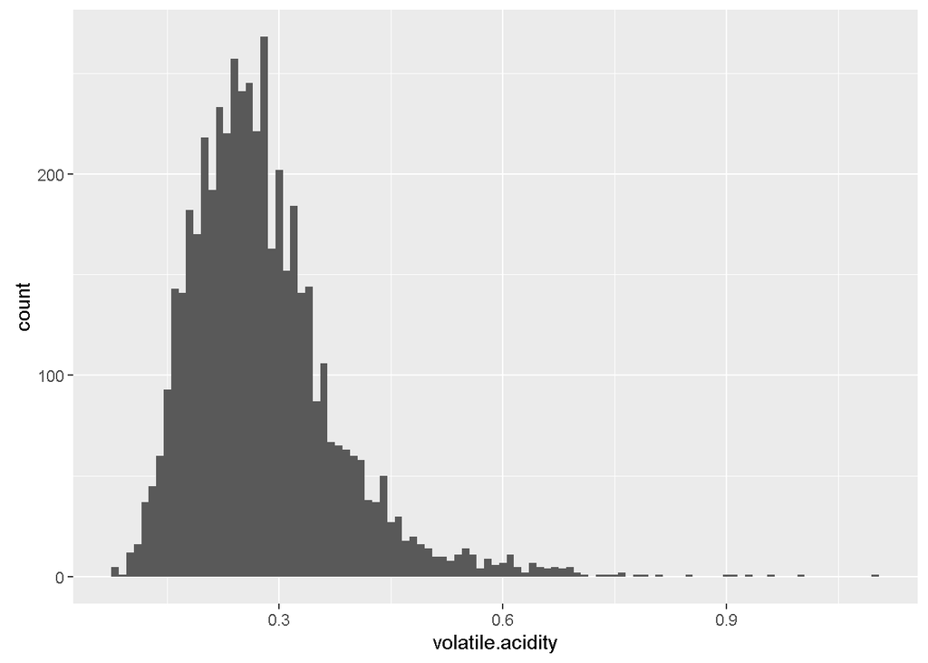

```
##    Min. 1st Qu.  Median    Mean 3rd Qu.    Max.
##  0.0800  0.2100  0.2600  0.2782  0.3200  1.1000
```

Volatile Acidity also looks normally distributed. It is positively skewed. There are more than a few outliers. Volatile Acidity may be helpful in further analysis due to its relation with pH and Fixed Acidity.

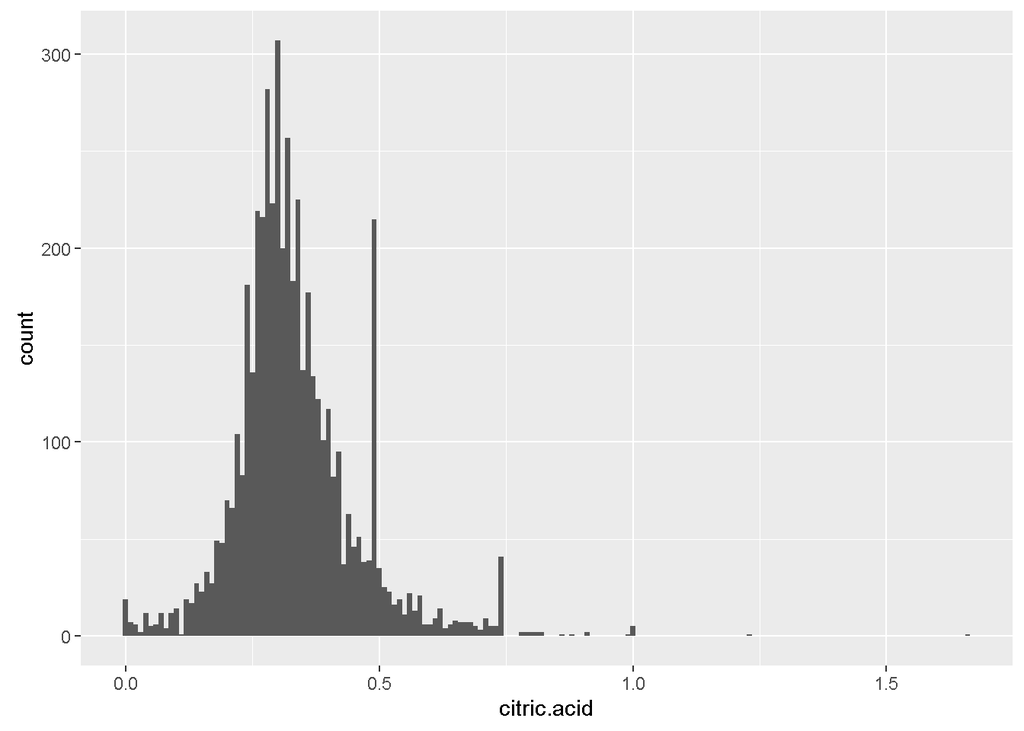

```
##    Min. 1st Qu.  Median    Mean 3rd Qu.    Max.
##  0.0000  0.2700  0.3200  0.3342  0.3900  1.6600
```

Interestingly, there are relatively many wines with 0.49 and 0.74 Citric Acid values. Apart from that, distributions look normal so far. There is an extreme outlier here with value 1.66. Since the acidity attributes (i.e. Fixed Acidity, Volatile Acidity and Citric Acid) are related each other, I believe those three may be significant in further analysis.

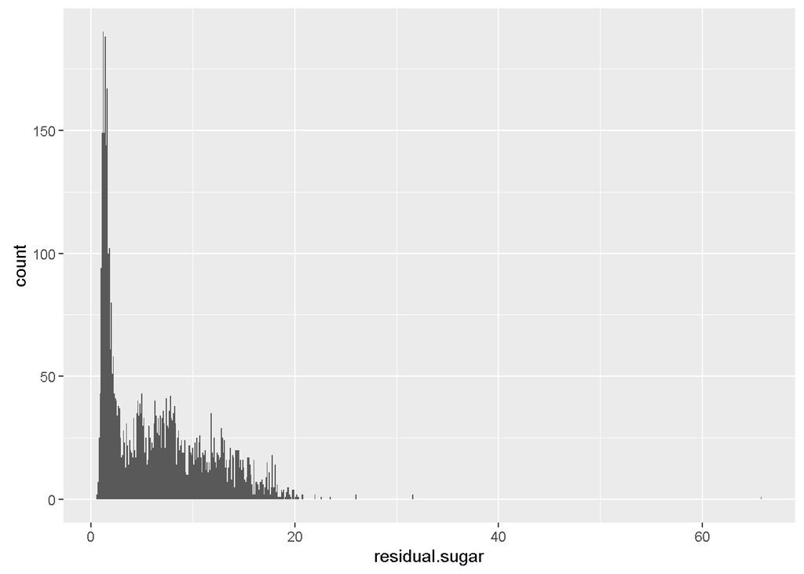

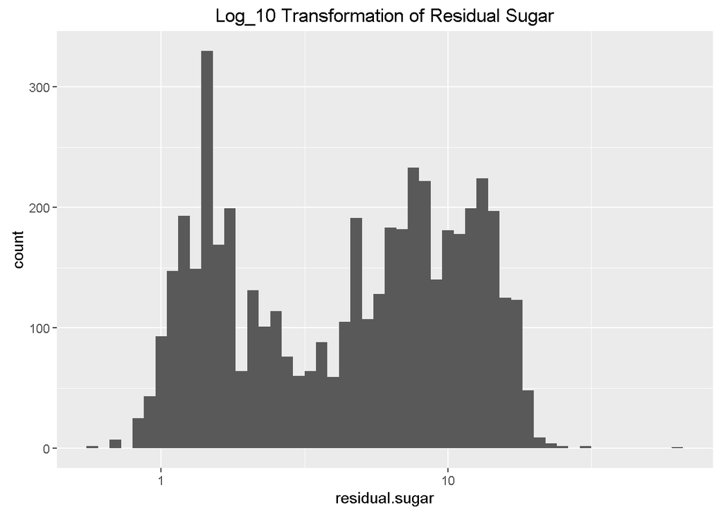

```
##    Min. 1st Qu.  Median    Mean 3rd Qu.    Max.
##   0.600   1.700   5.200   6.391   9.900  65.800
```

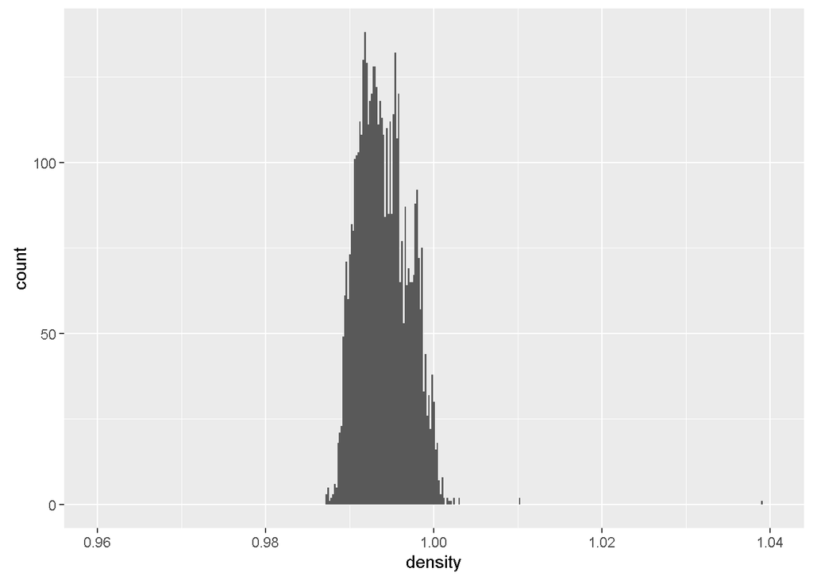

```
##    Min. 1st Qu.  Median    Mean 3rd Qu.    Max.
##  0.9871  0.9917  0.9937  0.9940  0.9961  1.0390
```

```
## [1] "Lower bound of range: 0.98878"
```

```
## [1] "Upper bound of range: 1.0003"
```

```
## [1] "Standard Deviation: 0.00279160061693161"
```

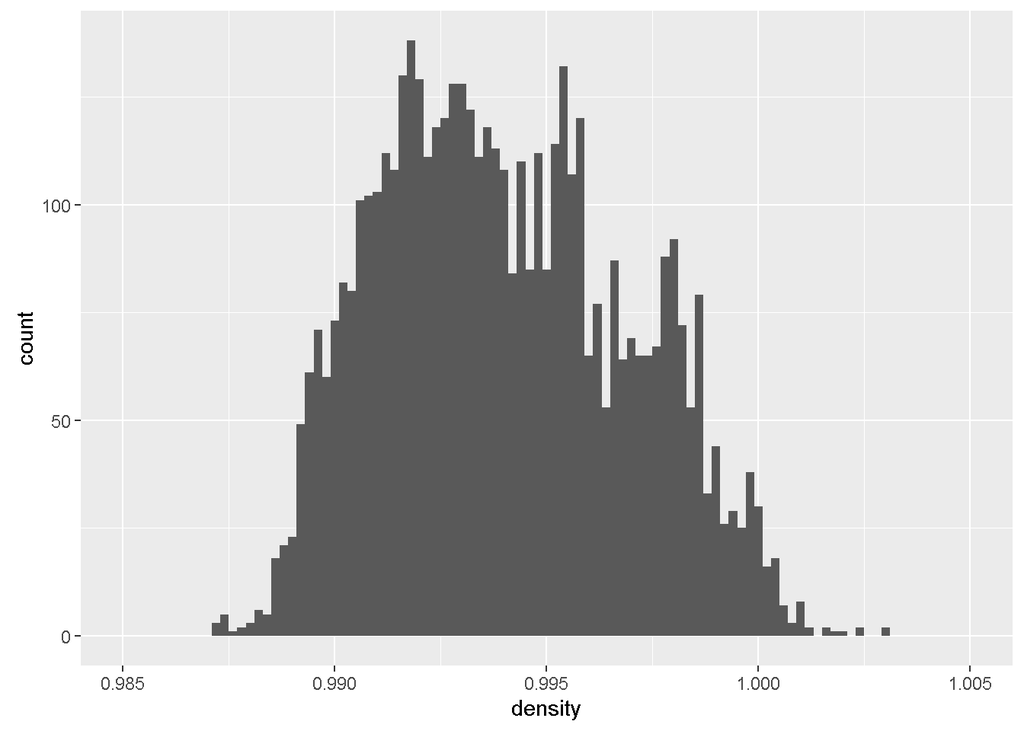

For better understanding of Density, x axises are limited by omitting outliers. Although Standard Deviation is very small, I think Density may be somehow correlated with Quality. There are some peaks through the distribution. However, mean and median very close to each other and by looking the chart itself, it doesn’t look like skewed. Excluding outliers, range and variance for Density are relatively small.

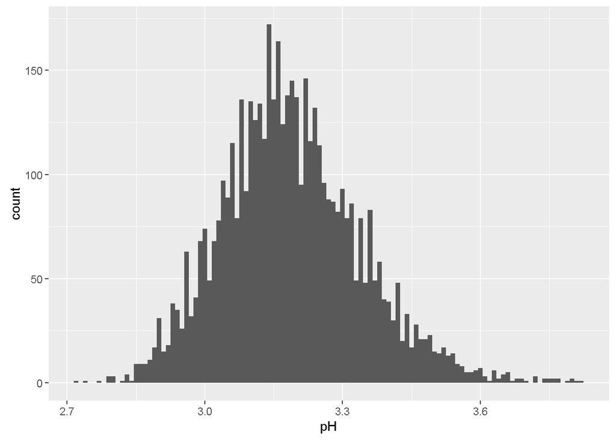

```
##    Min. 1st Qu.  Median    Mean 3rd Qu.    Max.
##   2.720   3.090   3.180   3.188   3.280   3.820
```

pH also looks normally distributed, there are no extreme outliers, no skewness. Half of pH values are between 3.09 and 3.28 with mean 3.1882666.

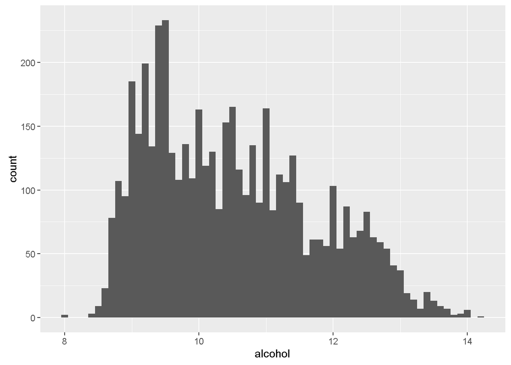

```
##    Min. 1st Qu.  Median    Mean 3rd Qu.    Max.
##    8.00    9.50   10.40   10.51   11.40   14.20
```

Alcohol values are distributed positively skewed. There are no extreme outliers as expected. The range is between 8 and 14.2. From gut feeling, I believe Alcohol plays a crucial role for the quality of a white wine.

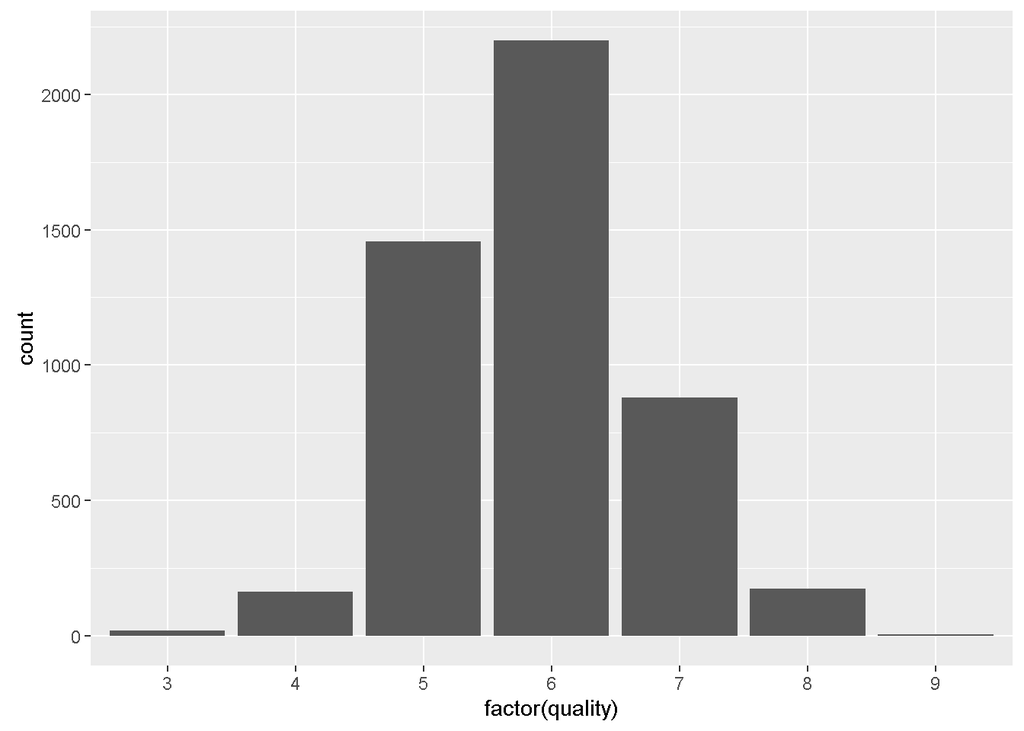

```
##    Min. 1st Qu.  Median    Mean 3rd Qu.    Max.
##   3.000   5.000   6.000   5.878   6.000   9.000
```

Quality is also normally distributed as expected with the range 6. It is interesting that there are just a few white wines with Quality score 3 or 9. So, there is no perfect white wine! There are also no white wine with a quality score of 0, 1 or 2.

# Univariate Analysis

### The structure of the dataset

There are 4,898 white wines in the dataset with 12 features (Fixed Acidity, Volatile Acidity, Citric Acid, Residual Sugar, Chlorides, Free Sulfur Dioxide, Total Sulfur Dioxide, Density, pH, Sulphates, Alcohol, and Quality). All variables are numeric.

### The main features of interest in the dataset

The main features in the data set are Residual Sugar, Density and Alcohol. I would like to determine which features are more significant to predict the Quality. I do not think all variables in the data set are significant to build a model to predict the Quality.

### Other features in the dataset that will help support the investigation into the features of interest

Acidity attributes (i.e. Fixed Acidity, Volatile Acidity and Citric Acid) may also be significant to predict the Quality as well as pH.

### The new variable created from existing variables in the dataset

I will add a factor variable attribute of Quality and some buckets in the further part of analysis.

### Unusual distributions, operations on the data to tidy, adjust, or change the form of the data

For better visualization, I mostly limit the x axis to get rid of outliers. I also make a Log_10 transformation to Residual Sugar since it is highly skewed, now it looks like a bimodal distribution with two peaks around 1.2 and 10.

# Bivariate Plots Section

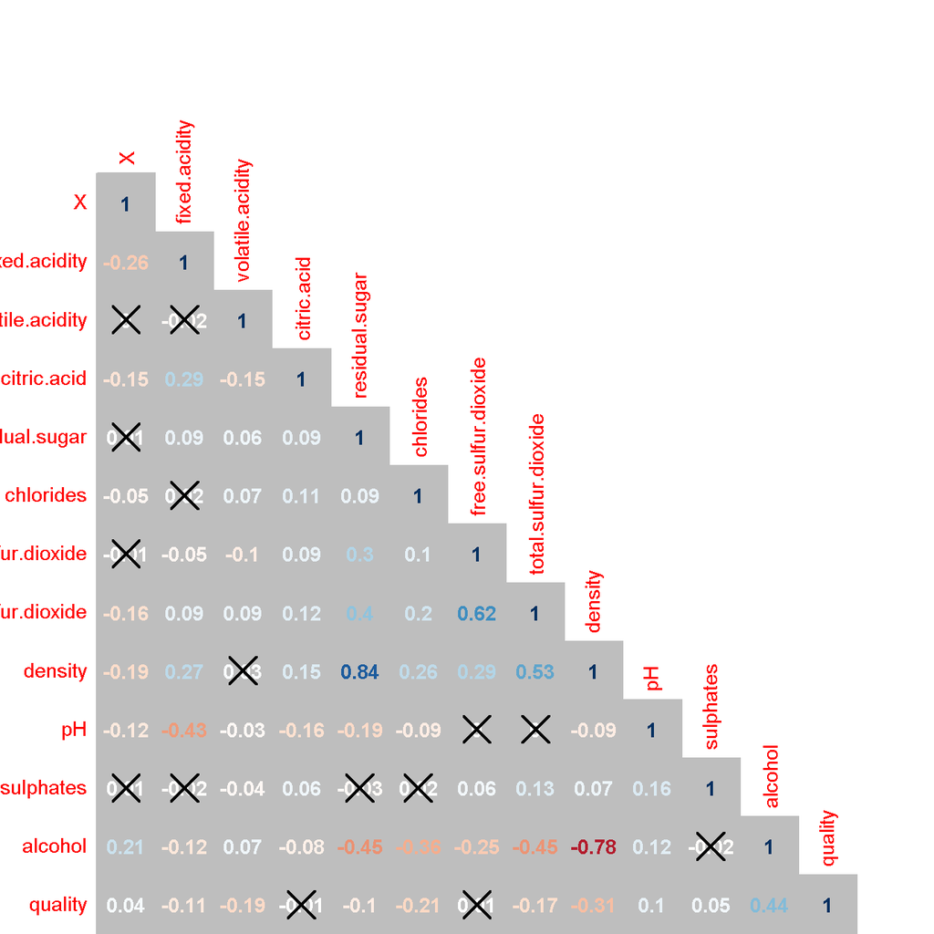

“X” denotes the pairs with insignificant p-values. Residual Sugar - Density and Alcohol - Density pairs have strong correlations. And, there are just weak correlations in Density - Quality and Alcohol - Quality.

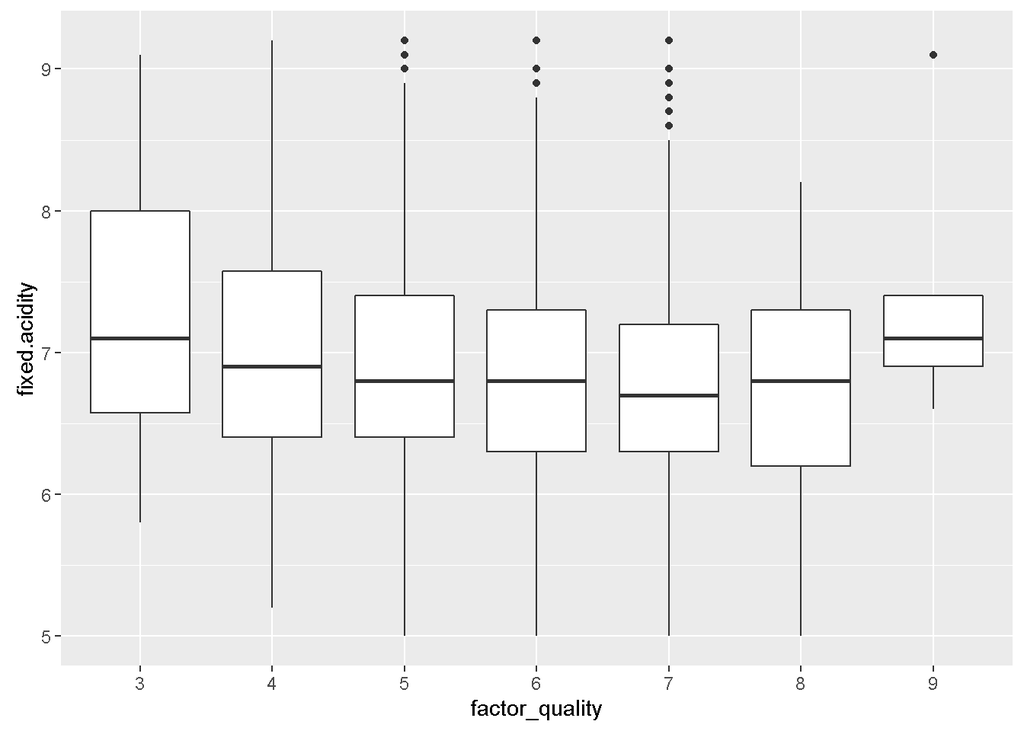

```
##
##  Pearson's product-moment correlation
##
## data:  df$quality and df$fixed.acidity
## t = -8.005, df = 4896, p-value = 1.48e-15
## alternative hypothesis: true correlation is not equal to 0
## 95 percent confidence interval:
##  -0.14121974 -0.08592991
## sample estimates:
##        cor
## -0.1136628
```

According to this box plot, less Fixed Acidity implies better Quality in the Quality range 3-7. However, there is no significant correlation between this pair. For better visualization, the lowest and highest 1% are omitted to remove outliers.

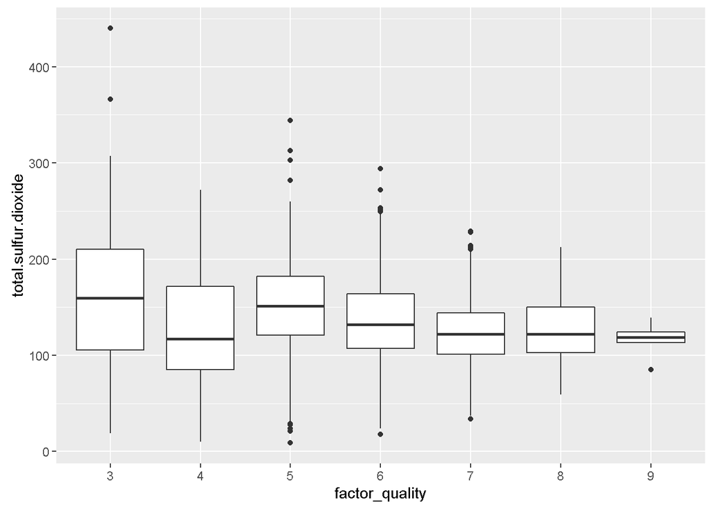

```
##
##  Pearson's product-moment correlation
##
## data:  df$quality and df$total.sulfur.dioxide
## t = -12.418, df = 4896, p-value < 2.2e-16
## alternative hypothesis: true correlation is not equal to 0
## 95 percent confidence interval:
##  -0.2017563 -0.1474524
## sample estimates:
##        cor
## -0.1747372
```

Although there is no significant correlation between Total Sulfur Dioxide and Quality, the box plot is interesting. The range is tend to decrease while Quality is increasing. So, this may indicate that Total Sulfur Dioxide may also have a significant effect to predict Quality score.

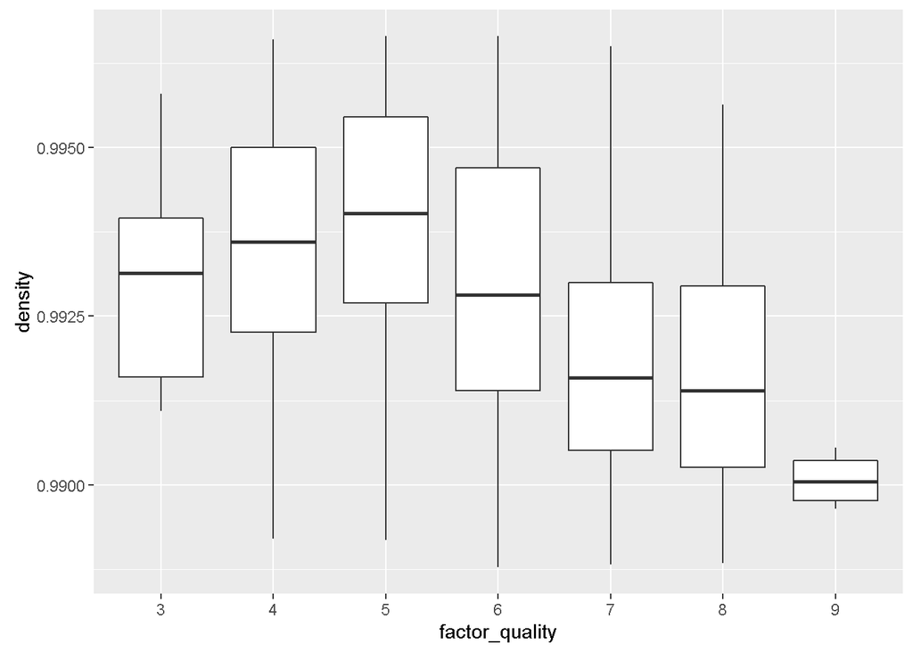

```
##
##  Pearson's product-moment correlation
##
## data:  df$quality and df$density
## t = -22.581, df = 4896, p-value < 2.2e-16
## alternative hypothesis: true correlation is not equal to 0
## 95 percent confidence interval:
##  -0.3322718 -0.2815385
## sample estimates:
##        cor
## -0.3071233
```

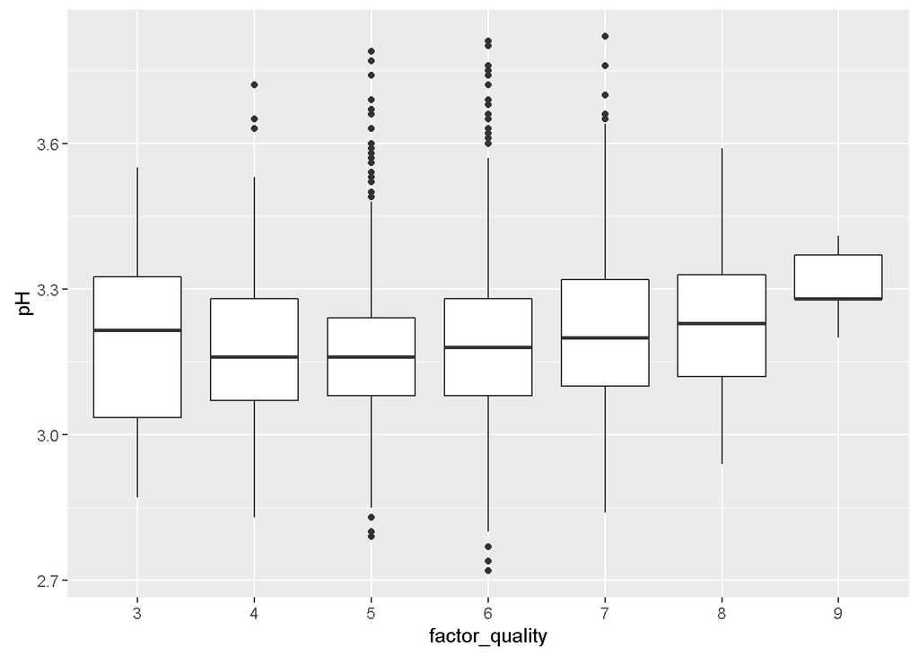

```
##
##  Pearson's product-moment correlation
##
## data:  df$quality and df$pH
## t = 6.9917, df = 4896, p-value = 3.081e-12
## alternative hypothesis: true correlation is not equal to 0
## 95 percent confidence interval:
##  0.07162022 0.12707983
## sample estimates:
##        cor
## 0.09942725
```

pH is negatively correlated in low qualities such as 3, 4 and 5 then it turns to a positive correlation. However, it is hard to say that there is a correlation with the value 0.0994272.

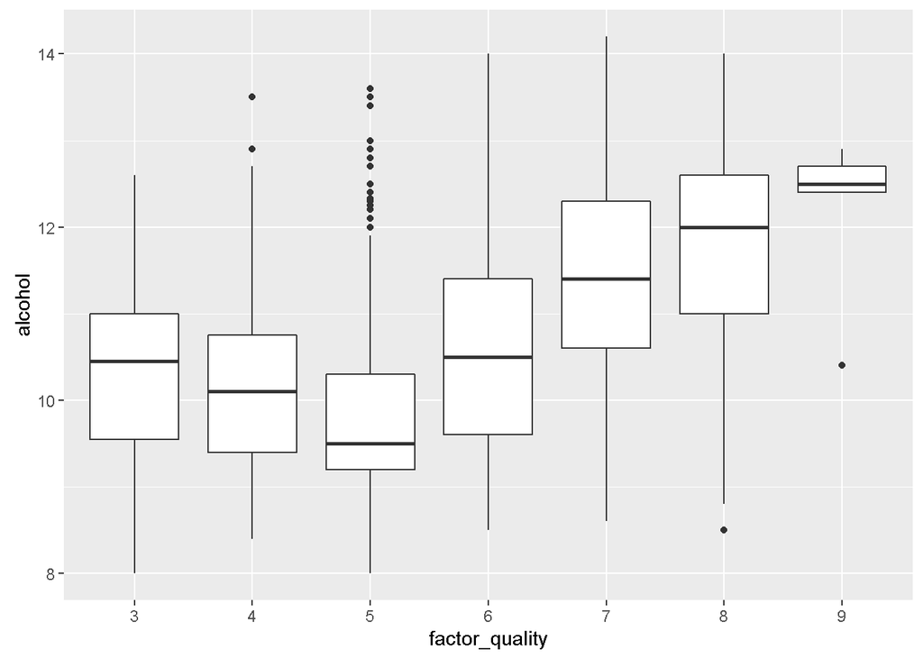

```
##
##  Pearson's product-moment correlation
##
## data:  df$quality and df$alcohol
## t = 33.858, df = 4896, p-value < 2.2e-16
## alternative hypothesis: true correlation is not equal to 0
## 95 percent confidence interval:
##  0.4126015 0.4579941
## sample estimates:
##       cor
## 0.4355747
```

It can visually be interpreted that Alcohol has some effect on Quality. It is negatively correlated in low qualities such as 3, 4 and 5 then it turns to a positive correlation, pH’s effect on Quality also acts like that. It is hard to comment on other’s effect on Quality visually. With the help correlation test, I can easily say that there is a correlation between Alcohol and Quality even it is moderate.

So, some correlated pairs can be visualized on scatter plots to understand the relations better.

```
## [1] "Strong Correlations"
```

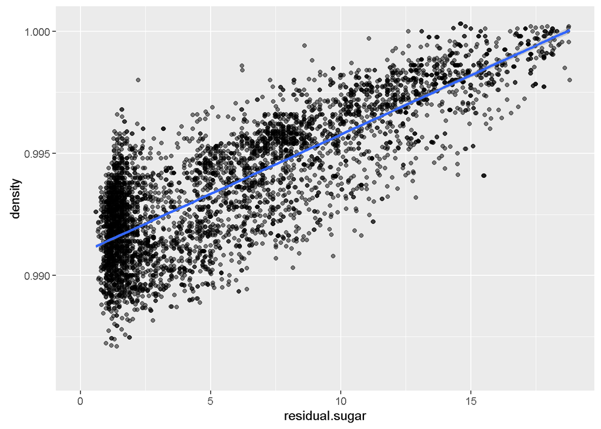

```
##
##  Pearson's product-moment correlation
##
## data:  df$density and df$residual.sugar
## t = 107.87, df = 4896, p-value < 2.2e-16
## alternative hypothesis: true correlation is not equal to 0
## 95 percent confidence interval:
##  0.8304732 0.8470698
## sample estimates:
##       cor
## 0.8389665
```

This pair has the strongest correlation among the other pairs in the dataset. It can also be seen visually in the above graph. This may occur due to Residual Sugar’s relatively higher density.

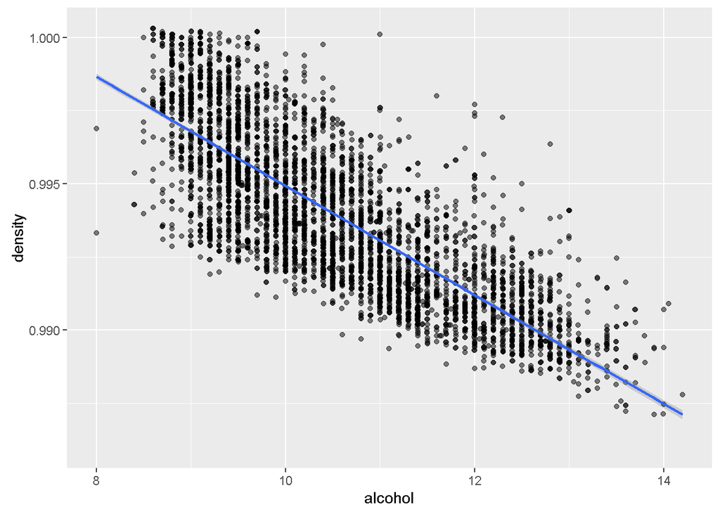

```
##
##  Pearson's product-moment correlation
##
## data:  df$density and df$alcohol
## t = -87.255, df = 4896, p-value < 2.2e-16
## alternative hypothesis: true correlation is not equal to 0
## 95 percent confidence interval:
##  -0.7908646 -0.7689315
## sample estimates:
##        cor
## -0.7801376
```

This pair has the second strongest correlation among the other pairs in the dataset with value -0.7801376. It can also be seen visually in the above graph. This may occur due to Alcohol’s relatively lower density like the effect of Residual Sugar on Density.

```
## [1] "Moderate Correlations"
```

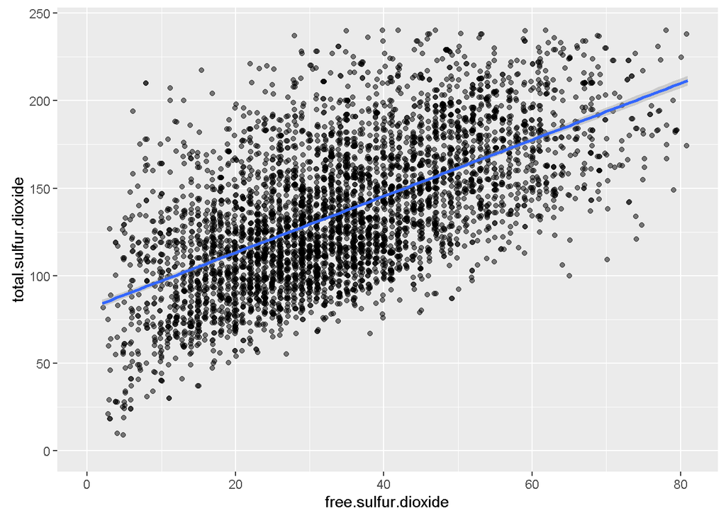

```
##
##  Pearson's product-moment correlation
##
## data:  df$free.sulfur.dioxide and df$total.sulfur.dioxide
## t = 54.645, df = 4896, p-value < 2.2e-16
## alternative hypothesis: true correlation is not equal to 0
## 95 percent confidence interval:
##  0.5977994 0.6326026
## sample estimates:
##      cor
## 0.615501
```

There is a moderate correlation between this pair. It makes sense because of this relation: total so2 = fixed + free so2. This is also the second strongest positive correlation among the other pairs in the dataset with value 0.615501.

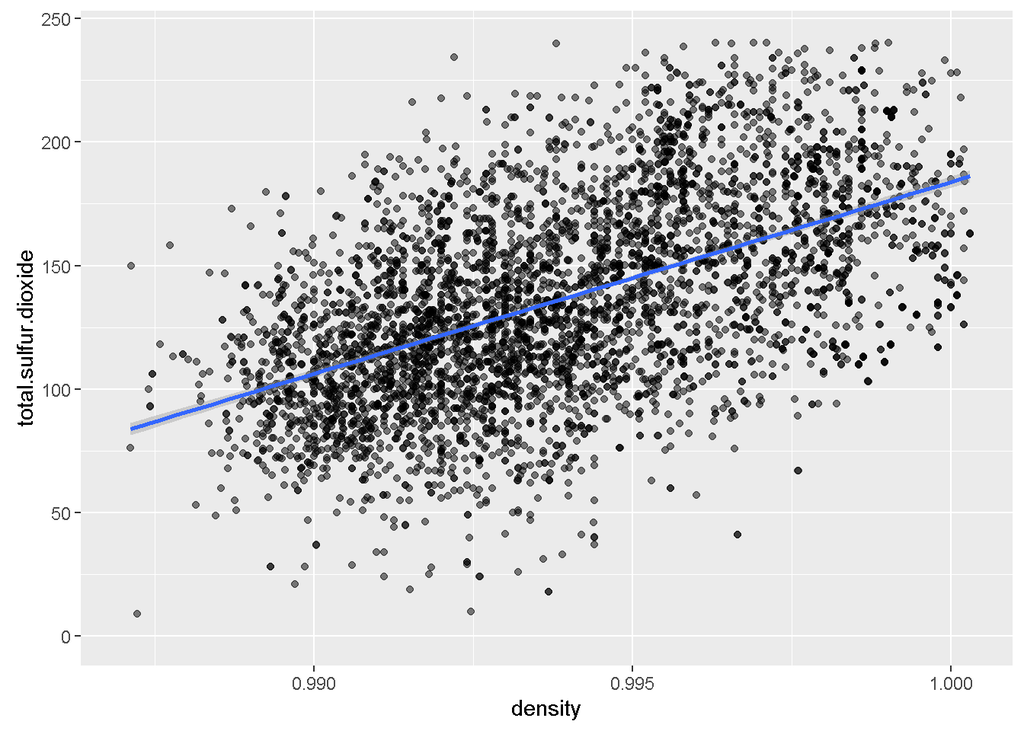

```
##
##  Pearson's product-moment correlation
##
## data:  df$density and df$total.sulfur.dioxide
## t = 43.719, df = 4896, p-value < 2.2e-16
## alternative hypothesis: true correlation is not equal to 0
## 95 percent confidence interval:
##  0.5094349 0.5497297
## sample estimates:
##       cor
## 0.5298813
```

This is the third strongest positive correlation among the other pairs in the dataset with value 0.5298813. Actually, I could not construct the logic behind this, so I would like to remind the principal “correlation doesn’t imply causation”.

Generally, as seen above scatter plots, many variable pairs have some correlations. However, power of correlations and their effects on Quality vary.

# Bivariate Analysis

### General observations

Interestingly, less Alcohol implies better Quality in the Quality range 3-5, but, in the Quality range 5-9, greater Alcohol refers better Quality. This exact relation can also be seen in pH with less variance. Even though Fixed Acidity and pH are related, Fixed Acidity only ensures the first part of the relation, less Fixed Acidity implies better Quality in the Quality range 3-5. In the second part, Density looks that has a great effect on wine quality, I mean, not in the Quality range 3-5, but in the Quality range 5-9, less Density implies better Quality according to related box plot. I also believe that too much Alcohol or pH also affect Quality in a bad way. In consequence, both too much and too little any attributes lower the quality of white wines, and this makes building a linear model harder due to the overfitting.

### Interesting relationships between the other features

Total and Free Sulfur Dioxide are moderately correlated, this is also third strongest correlation amongst the others. Since total so2 = fixed + free so2, this makes sense. In a similar manner, I was expecting alike relations in acidities, but only significant correlation is between pH and Fixed Acidity which also makes sense because pH is a quantitative assessment of Fixed Acidity.

### The strongest relationship

The strongest one is between Density and Residual Sugar, followed by the pair Alcohol - Density. However, only Density and Alcohol are directly correlated with Quality although the correlations are weak. Since Alcohol is already correlated with Density, this may be the reason. Furthermore, since Residual Sugar is strongly correlated wit Density, Residual Sugar may also have significant amount of effect on Quality.

# Multivariate Plots Section

Initially, three strongly correlated attributes can be visualized.

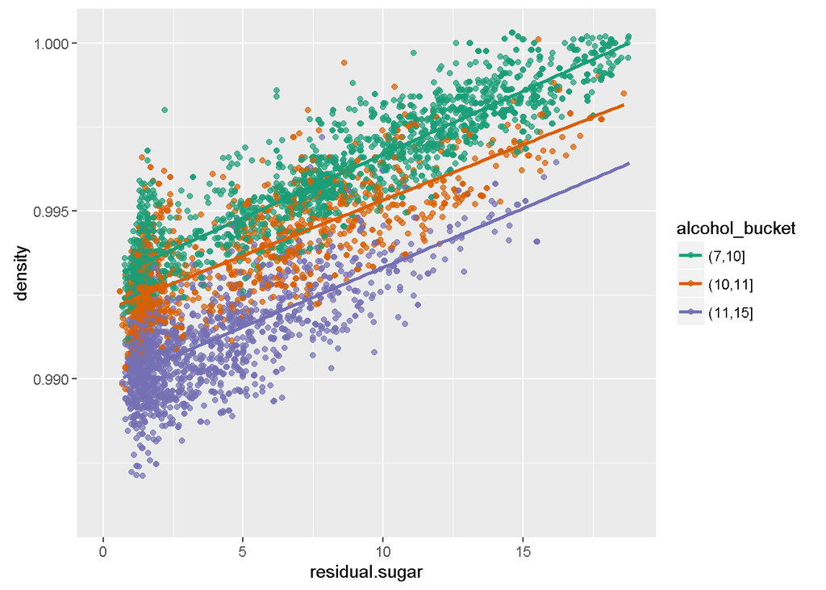

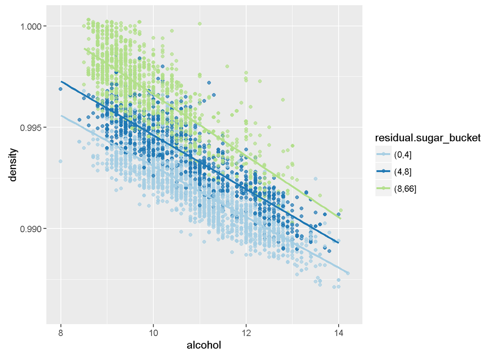

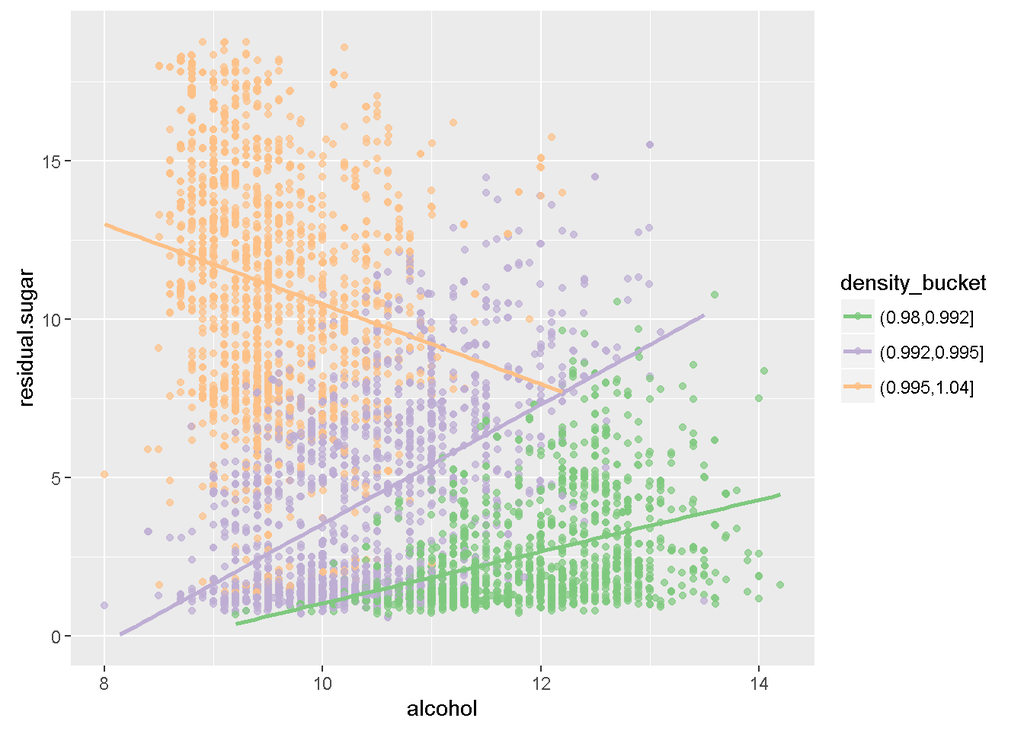

```
## [1] "Correlation of Residual Sugar and Density: 0.838966454904583"
```

```
## [1] "Correlation of Alcohol and Density: -0.780137621425558"
```

```
## [1] "Correlation of Residual Sugar and Alcohol: -0.450631222031729"
```

It looks that these variables have significant effects on each other, and two of them are strong. Furthermore, by looking above three scatter plots, one can easily distinguish the clusterings. There are obvious clusterings for Alcohol, Residual Sugar and Density on these strongly correlated pairs. Since Alcohol is the one which has most correlated pairs and it is the most correlated attribute with Quality, I think its pairs may also have some effects on Quality.

```
## [1] "Moderate Correlations"
```

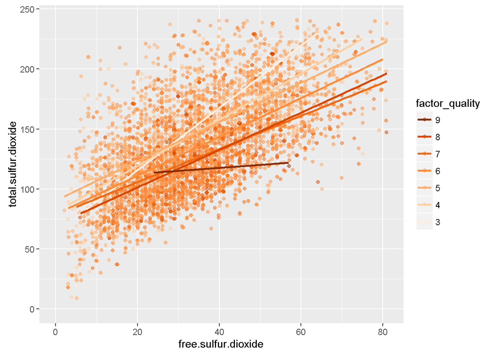

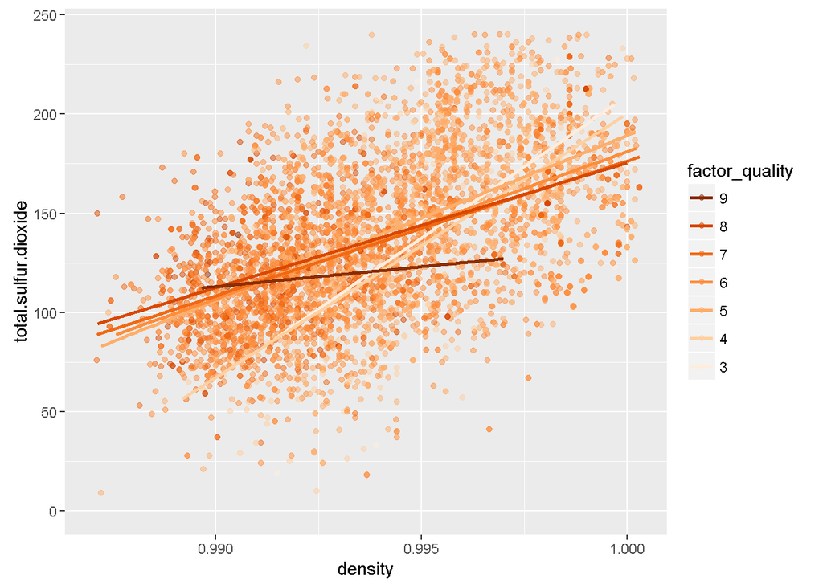

```
##                      free.sulfur.dioxide total.sulfur.dioxide    density
## free.sulfur.dioxide          1.000000000            0.6155010  0.2942104
## total.sulfur.dioxide         0.615500965            1.0000000  0.5298813
## density                      0.294210411            0.5298813  1.0000000
## quality                      0.008158067           -0.1747372 -0.3071233
##                           quality
## free.sulfur.dioxide   0.008158067
## total.sulfur.dioxide -0.174737218
## density              -0.307123313
## quality               1.000000000
```

Until this part of the analysis one can think that there might be remarkable clustering or more heterogeneous distributions of Quality on the pairs, but there are not. This may also make building model harder than I thought. Unlike the strongly correlated trio, Quality factors are almost homogeneously distributed in these two moderately correlated pairs.

```
##
## Calls:
## m1: lm(formula = quality ~ alcohol, data = df)
## m2: lm(formula = quality ~ alcohol + density, data = df)
## m3: lm(formula = quality ~ alcohol + density + residual.sugar, data = df)
## m4: lm(formula = quality ~ alcohol + density + residual.sugar + pH,
##     data = df)
## m5: lm(formula = quality ~ alcohol + density + residual.sugar + pH +
##     volatile.acidity, data = df)
## m6: lm(formula = quality ~ alcohol + density + residual.sugar + pH +
##     volatile.acidity + free.sulfur.dioxide, data = df)
##
## ===============================================================================================
##                           m1          m2          m3          m4           m5          m6
## -----------------------------------------------------------------------------------------------
##   (Intercept)           2.582***  -22.492***   90.313***   116.411***   97.650***   93.231***
##                        (0.098)     (6.165)    (12.374)     (12.781)    (12.392)    (12.387)
##   alcohol               0.313***    0.360***    0.246***     0.209***    0.253***    0.265***
##                        (0.009)     (0.015)     (0.018)      (0.019)     (0.018)     (0.018)
##   density                          24.728***  -87.886***  -115.741***  -96.535***  -92.224***
##                                    (6.079)    (12.317)     (12.791)    (12.404)    (12.397)
##   residual.sugar                                0.053***     0.066***    0.064***    0.059***
##                                                (0.005)      (0.005)     (0.005)     (0.005)
##   pH                                                         0.596***    0.528***    0.495***
##                                                             (0.079)     (0.076)     (0.076)
##   volatile.acidity                                                      -2.024***   -1.965***
##                                                                         (0.109)     (0.109)
##   free.sulfur.dioxide                                                                0.004***
##                                                                                     (0.001)
## -----------------------------------------------------------------------------------------------
##   R-squared                 0.2        0.2         0.2          0.2         0.3         0.3
##   adj. R-squared            0.2        0.2         0.2          0.2         0.3         0.3
##   sigma                     0.8        0.8         0.8          0.8         0.8         0.8
##   F                      1146.4      583.3       434.1        343.5       363.8       309.5
##   p                         0.0        0.0         0.0          0.0         0.0         0.0
##   Log-likelihood        -5839.4    -5831.1     -5776.8      -5748.5     -5580.3     -5566.4
##   Deviance               3112.3     3101.8      3033.7       2998.8      2799.8      2784.0
##   AIC                   11684.8    11670.3     11563.6      11509.0     11174.6     11148.9
##   BIC                   11704.3    11696.2     11596.1      11547.9     11220.1     11200.9
##   N                      4898       4898        4898         4898        4898        4898
## ===============================================================================================
```

Although this is the best model I build, it does not look like a good predictor.

# Multivariate Analysis

### General observations

There are obvious clusterings for Alcohol, Residual Sugar and Density on strongly correlated pairs. Since Alcohol is the one which has most correlated pairs and it is the most correlated attribute with Quality, I think its pairs may also have some effects on Quality.

### Interesting interactions between features

I thought there might be remarkable clustering or more heterogeneous distributions of Quality on the pairs, but there are not. This may also make building model difficult.

### Linear model

The model was created by using 6 attributes. And final R-squared value is 0.2751821. Considering the R-squared value of initial one featured (i.e. Alcohol) model is 0.1897253, it does not look like a good predictor. So it can be said that the quality of a white wine is hard to predict before tasting. We should appreciate white wine tasters. Or, perhaps, additional data such as grape type or age are needed to build a significant model.

# Final Plots and Summary

### Plot One

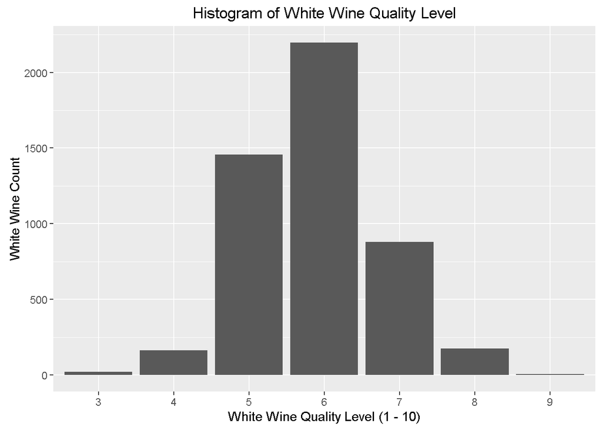

```
##    3    4    5    6    7    8    9
##   20  163 1457 2198  880  175    5
```

### Description One

Quality is normally distributed as expected with the range 6. There are just a few white wines with Quality score 3 or 9. So, there is no perfect white wine with the score 10. There are also no white wine with a quality score of 0, 1 or 2. This figure is important to comprehend the distribution of the quality scores on white wines in the dataset.

### Plot Two

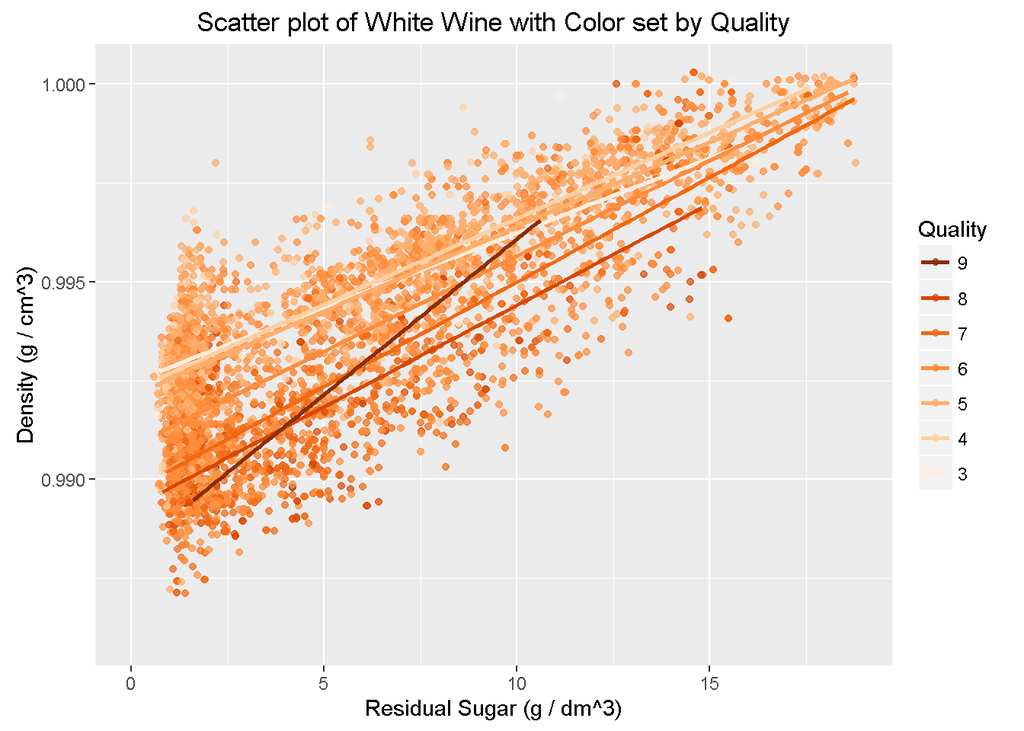

```
## [1] "Correlations between Density and Residual Sugar"
```

```
## [1] "For Quality score 3 : 0.708567954467321"
## [1] "For Quality score 4 : 0.745169719274969"
## [1] "For Quality score 5 : 0.893388909528408"
## [1] "For Quality score 6 : 0.855632919226792"
## [1] "For Quality score 7 : 0.822813056675261"
## [1] "For Quality score 8 : 0.818292602587863"
## [1] "For Quality score 9 : 0.948667382184295"
```

### Description Two

Unlike the plot one and three, Quality levels are not distinguished well in scatter plots. Thus, and clustering are harder for Quality levels, graph with parameters such as mean, median and count are better visualizations for Quality. I believe this figure is a good example that Quality is hard to predict with the attributes in this dataset.

### Plot Three

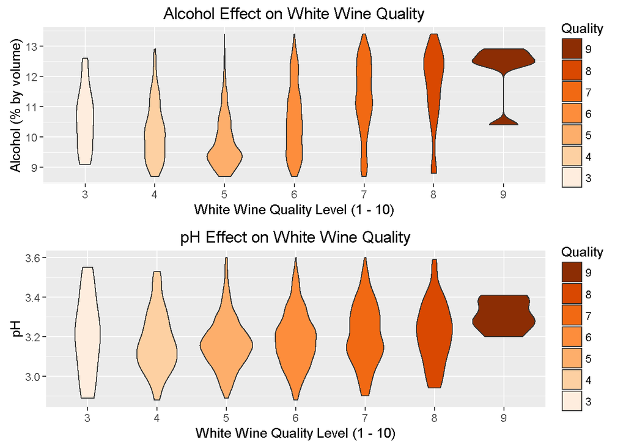

### Description Three

In addition to traditional box plots, violin plots also support the argument that less Alcohol implies better Quality in the Quality range 3-5, but, in the Quality range 5-9, greater Alcohol refers better Quality. This exact relation can also be seen in pH with less variance. Wider parts in the plots indicate greater number of white wines with those attribute values. So, with the support of this figure, it can easily be said that Alcohol has a significant effect on Quality.

### Summary

There are many attributes to define the quality of a white wine. Even though some inferences can be made to predict or comment on a white wine quality, it is really hard to make a significant decision about Quality according to this analysis with this dataset. However, it can be said that Alcohol and pH have some effects on Quality depending on Quality range. And, according the final linear model, we can only explain about 27.52% of Quality variance with these attributes. This states that there are many other attributes outside of this dataset that affect the quality of a white wine.

# Reflection

Despite considering myself a good wine drinker, I was not aware of many of these attributes until the analysis. So, the first difficulty is to have an idea about all attributes in the dataset in order to perform an efficient analysis.

In order to comprehend the relations between attributes, there was a need to plot all combinations. This means 11 plots in univariate section, 11x11 plots in bivariate section and more than 11x11x11 plots multivariate section. However, the correlation matix made this the entire process much easier.

There were also lots of syntax errors throughout the analysis, fortunately there are many sources about R on the internet. And, R community is very helpful about any kind of problems.

Understanding the Alcohol effect on Quality is the breakthrough of the analysis, afterwards things went better by focusing on that.

As already stated in the summary section, I believe additional features will be helpful to build better models. The dataset can be enriched with the information of grape type, age of wine or other chemical components of white wines for future analyses.